# Tuning random forest hyperparameters

2022-12-14

## Introduction

## Random forests

*Main idea*: combine many decision trees to classify an observation

At each split, only a fraction of the predictors are sampled to consider a split.

## Hyperparameters

- Number of trees
- Number of candidate predictors
- Proportion of the sample used for fitting the tree
- Sample with or without replacement
- Minimum node size
- Split rule

## Tuning

Trying multiple options to find the best values!

## Previous research

Default values can lead to good *accuracy*, but *discrimination* and *calibration* are typically bad.

## Current research

How can we tune hyperparameters to improve overall model performance, taking computational intensivity into account?

Three studies:

- *Study 1: which hyperparameters to tune?*
- Study 2: what metric to optimise?
- Study 3: which hyperparameter search strategy to use?

## Methods

## Data simulation

Vary data characteristics:

- Number of predictors: 8, 16, 32
- Event fraction: 0.1, 0.3, 0.5
- Sample size: 0.5\(n\), \(n\), 2\(n\) (\(n\) the required sample size to detect predictor effects for an AUC of 0.8; Riley et al. (2020))

Simulated using **logistic regression with strong interactions**: \[\begin{align} P(y_i = 1) & = \frac{exp(\mathbf\beta\mathbf{X})}{1 + exp(\mathbf\beta\mathbf{X})} \\& = \frac{exp(\beta_0 + \beta*\sum_{j=1}^px_{ij} + \gamma*\sum_{j=1}^{0.25*p}x_{ij}*x_{i(j+0.5p)})}{1 + exp(\beta_0 + \beta*\sum_{j=1}^px_{ij} + \gamma*\sum_{j=1}^{0.25*p}x_{ij}*x_{i(j+0.5p)})} \end{align}\]

## Data simulation

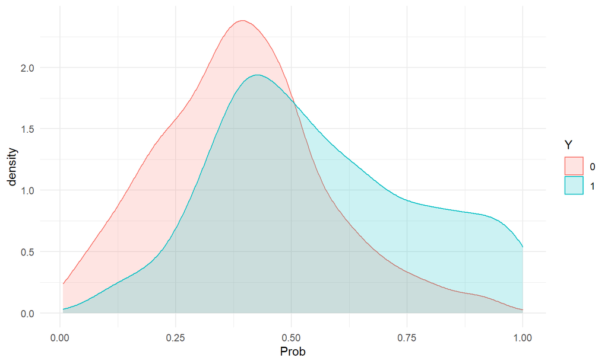

## Manipulations

Vary hyperparameters that are tuned when fitting a random forest.

Always tuned:

- Number of predictors
- Minimum node size

All combinations of:

- Number of trees
- Sample fraction
- Sampling with replacement
- Split rule

## Settings

```r
hyperparameter_combinations <- expand.grid(
  mtry = TRUE,
  sample.fraction = c(TRUE, FALSE),
  num.trees = c(TRUE, FALSE),
  replace = c(TRUE, FALSE),
  min.node.size = TRUE,
  splitrule = c(TRUE, FALSE)
)
hyperparameter_combinations <- rbind(rep(FALSE, ncol(hyperparameter_combinations)),
                                     hyperparameter_combinations)
```

## Results

## Mean performances

|  | Metric | Tuned hyperparameters | Performance mean | Performance SD |
| --- | --- | --- | --- | --- |
| 1 | Accuracy |  | 0.6553 | 0.00169705627484768 |
| 2 | Accuracy | mtry + min.node.size | 0.6598 | 0.000848528137423842 |
| 3 | Accuracy | mtry + min.node.size + splitrule | 0.6515 | 0.0014142135623731 |
| 4 | Accuracy | mtry + num.trees + min.node.size | 0.6565 | 0.00353553390593274 |
| 5 | Accuracy | mtry + num.trees + min.node.size + splitrule | 0.6636 | 0.00311126983722078 |
| 6 | Accuracy | mtry + num.trees + replace + min.node.size | 0.6554 | 0.00367695526217003 |
| 7 | Accuracy | mtry + num.trees + replace + min.node.size + splitrule | 0.65915 | 0.00360624458405139 |
| 8 | Accuracy | mtry + replace + min.node.size | 0.65735 | 0.00318198051533943 |
| 9 | Accuracy | mtry + replace + min.node.size + splitrule | 0.66215 | 0.00219203102167829 |
| 10 | Accuracy | mtry + sample.fraction + min.node.size | 0.66095 | 0.000919238815542489 |

[output cut: 126 more lines]

## Discussion

[figure not shown]

## References

Riley, Richard D., Joie Ensor, Kym I. E. Snell, Frank E. Harrell, Glen P. Martin, Johannes B. Reitsma, Karel G. M. Moons, Gary Collins, and Maarten van Smeden. 2020. “Calculating the Sample Size Required for Developing a Clinical Prediction Model.” *BMJ* 368 (March): m441. https://doi.org/10.1136/bmj.m441.